# StatQuest_1_R-Std_Errors_explained

Delmotte Jean

5 juillet 2018

from : https://www.youtube.com/watch?v=XNgt7F6FqDU&t=611s Au programmme : - Standart erors - Bootstraping (en bonus)

# Error Bars :

bar d’erreurs qui sont lié fortement aux erreurs standart !

## Dataset :

Création d’un dataset nommé “donnes” :

```r
donnees <- data.frame(A=c(18,17,17,17,12,5,10,8), B=c(8,12,15,10,1,5,20,7), C=c(18,15,16,14,13,17,15,15), row.names=c("ind1","ind2","ind3","ind4","ind5","ind6","ind7","ind8"))
donnees
```

```
##       A  B  C
## ind1 18  8 18
## ind2 17 12 15
## ind3 17 15 16
## ind4 17 10 14
## ind5 12  1 13
## ind6  5  5 17
## ind7 10 20 15
## ind8  8  7 15
```

Les données sont plot sur un scatterplot : (Marche pas :( )

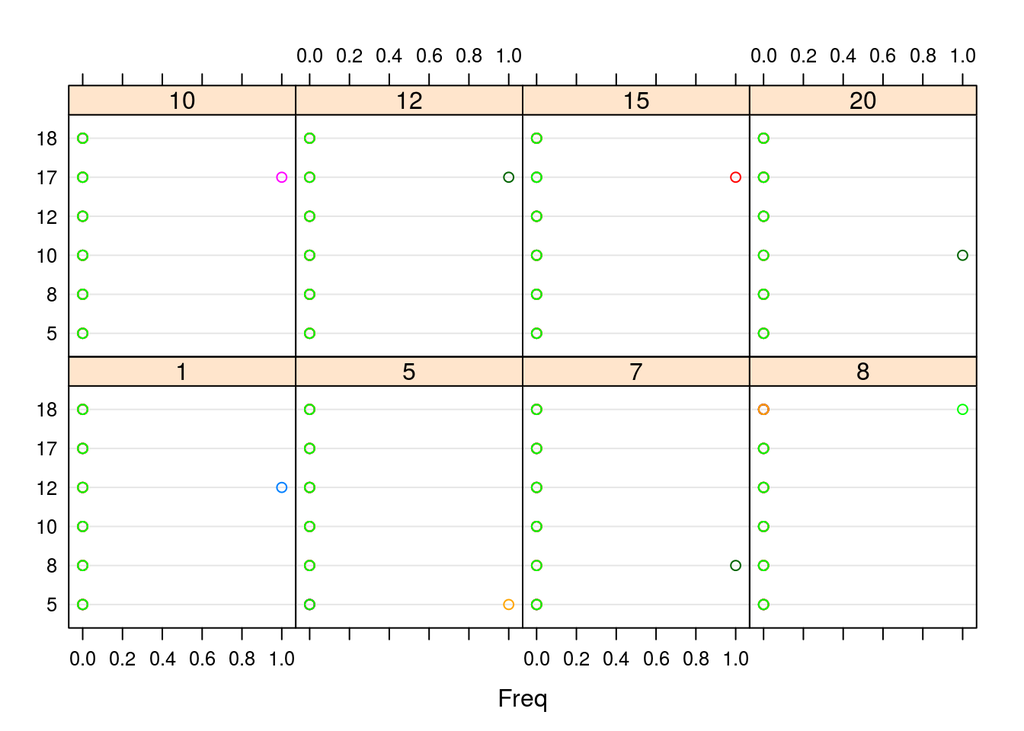

```r
dotplot(donnees, use.cols = FALSE)
```

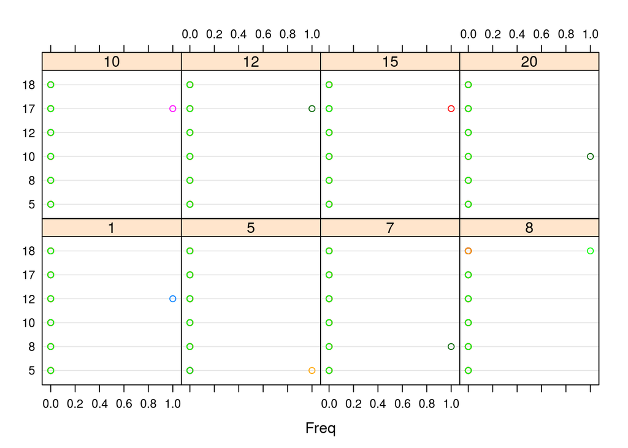

```r
#donnees <- t(donnees)
dotplot(donnees)
```

```r
#ggplot(donnees, aes(x= donnees$A)) + geom_bar()
#View(donnees)
```

On peut calculer la moyenne et la écart type (standart deviation) pour chaque valeur :

- la fonction mean() pour calculer la moyenne d’un vecteur
- la fonction sd() pour calculer l’écart type

On peut ensuite mettre ça dans un dataframe pour plus de visibilité :

```r
# A
mean(donnees$A)
```

```
## [1] 13
```

```r
sd(donnees$A)
```

```
## [1] 4.956958
```

```r
stat <- data.frame(A=c(mean(donnees$A), sd(donnees$A)), B=c(mean(donnees$B), sd(donnees$B)), C=c(mean(donnees$C), sd(donnees$C)), row.names=c("moyenne","ecart type"))
stat
```

```
##                    A        B        C
## moyenne    13.000000 9.750000 15.37500
## ecart type  4.956958 5.946187  1.59799
```

**Remarque :** Sur R il existe un fonction pour afficher tout les stat d’une coup : - summary() pour “résumé” :

```r
summary(donnees)
```

```
##        A              B               C
##  Min.   : 5.0   Min.   : 1.00   Min.   :13.00
##  1st Qu.: 9.5   1st Qu.: 6.50   1st Qu.:14.75
##  Median :14.5   Median : 9.00   Median :15.00
##  Mean   :13.0   Mean   : 9.75   Mean   :15.38
##  3rd Qu.:17.0   3rd Qu.:12.75   3rd Qu.:16.25
##  Max.   :18.0   Max.   :20.00   Max.   :18.00
```

En effet on peut observé la moyenne, la médiane et les différents quartiles (à détailler plus tard dans un prochain cours)

## On peut aussi afficher les données sous forme de “dynamite plot” :

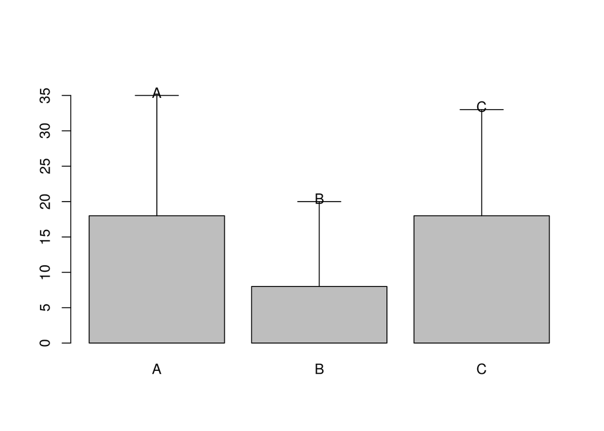

```r
dynamitePlot <- function(height, error, names = NA,
        significance = NA, ylim = c(0,maxLim)){
    maxLim <- 1.1* max(mapply(sum, height, error))
    bp <- barplot(height, names.arg = names, ylim = ylim)
    arrows(x0 = bp, y0 = height, y1 = height + error, angle = 90)
    text(x = bp, y = 0.4 + height + error, labels = significance)
}

stat <- as.matrix(donnees) # il faut que les données soient des matrices et non des dataframes

Sig <- c("A", "B", "C")
dynamitePlot(stat[1,], stat[2,], names = colnames(donnees), significance = Sig)
```

# Il existe 3 types commun de bars d’erreur :

## 1. Ecart type : (standard deviations abrégé sd)

- Il nous renseigne sur : comment les données sont distribués autour de la moyenne
- Un grand écart type nous indique que certaine des données sont loin de la moyenne
- Dans la plupart des cas, c’est cettre barre d’erreur qui est a utiliser dans les graphs comme il nous rensigne sur la distribution des données

## 2. Erreurs standard

- Elle nous rensegne sur comment les moyennes sont distribué (et pas les datas)

## 3. Interval de confience (Confidence Intervals)

- Elles sont relié aux erreurs standart, elles seront expliqué d’avantage dans un autre cours.

## commençont par regardé un distribution standard :

- Génération d’une distribution normal, on peut imaginé qu’il s’agit de du poid d’un grand nombre de souris

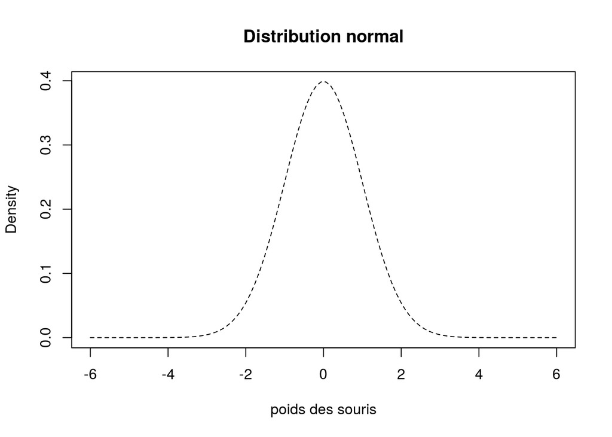

```r
x <- seq(-6, 6, length=100) #génération vecteurs de taille 100 de -4 à 4
hx <- dnorm(x) # donne les valeurs de la densité de la loi normale centré réduite d'un vecteur de nombre

normal <- plot(x, hx, type="l", lty=2, xlab="poids des souris",
  ylab="Density", main="Distribution normal")
```

Sur **l’axe x** on met le poids de chaque souris Sur **l’axe y** on met la proportion de souris pour un poids donnée

### Interprétation du graphique :

- La plupart des souris ont un poid proche de la moyenne (qui est centré à 0)
- Un petite portion des souris on un poid un peu plus *petit* que la moyenne
- Un petite portion des souris on un poid un peu plus *grand* que la moyenne

En générale il n’est pas possible de mesuré tout le souris donc on prends juste 5 mesures

```r
mesure <- c(0.1, 0.8, 3.5, 1.9, 2.3)
mesure
```

```
## [1] 0.1 0.8 3.5 1.9 2.3
```

Maintenant nous allons calculé l’écart type (deviation standard) :

-L’écart type étant une mesure de dispersion des valeurs autours de leurs moyenne arithmétique : 1) Calculont d’abort la moyenne :

Pour rappelle $\bar{x} = 1/n \sum_{i=1} x_i$ , avec ici n = 5

sur R

```r
moyenne = (0.1 + 0.8 + 3.5+ 1.9+ 2.3)/(length(mesure))
moyenne
```

```
## [1] 1.72
```

Ou plus simplement :

```r
moyenne <- mean(mesure)
moyenne
```

```
## [1] 1.72
```

2. calculont l’écart type :
- Par définition : l’écart-type est la moyenne quadratique des écarts à la moyenne $\bar{x}$ . On le note habituellement s ou sd (de l’anglais **s**tandard deviation)

$\sqrt{ 1/(n-1) \sum_{i} (x_i -\bar{x})² }$

Soit pour notre exemple :

$\sqrt{1/(5-1) [ (0.1-1.72)² + (0.8-1.72)² + (3.5-1.72)² + (1.9-1.72)² + (2.3-1.72)² ]} = 1.323631$

```r
somme <- 0
for (i in mesure) {
  somme <- ((i-moyenne)*(i-moyenne) + somme) # On peut remplacé moyenne par 1.72
}
somme
```

```
## [1] 7.008
```

```r
ecarType <- sqrt((1/(length(mesure)-1))* somme)
ecarType
```

```
## [1] 1.323631
```

Ou plus simplement :

```r
sd(mesure)
```

```
## [1] 1.323631
```

On remarquera que dans $\sqrt{ 1/(n-1) \sum_{i} (x_i -\bar{x})² }$ on divise par $n-1$